[figure not shown]

In this series we are trying to reproduce the models and examples listed in the book “Analysis of Financial Time Series, 3rd Edition”, by Ruey S. Tsay, using Stan https://mc-stan.org/ and the package RStan https://cran.r-project.org/web/packages/rstan/index.html. The main repository for the presented models and data can be found at https://github.com/marcomarconi/AFTS_with_Stan.

```r
{
  require(tidyverse)
  require(rstan)
  require(bayesplot)
  require(loo)
  require(LaplacesDemon)
  library(xts)
  library(quantmod)
  library(FKF)
  library(MARSS)
  library(forecast)
  library(NTS)

  rstan_options(auto_write = TRUE)
  rstan_options(javascript = FALSE)
  theme_set(theme_classic(base_size = 24))
}
```

## 5.4 Models for Price Change - Decomposition Model

When analyzing high frequency intraday data it is common to encounter long periods of “no change” in price data. In order to account for this phenomenon we are going to see the ADS Decomposition model. In this model price change is decomposed into three components: indicator for price change, the direction of price movement if there is a change, and the size of price change if a change occurs. Specifically, the price change at the *i*th transaction can be written as:

$$y_i = P_{t_i} - P_{t_i-1} = A_iD_iS_i$$

```stan
functions {
  real geometric(int y, real phi){
    return(log(phi * (1 - phi)^y));
  }
  real ADS_loglikelihood(vector I, int A, int D, int S, real peta, real eta, real lambda_u, real lambda_d){
    return(I[1] * log(1 - peta) +
           I[2] * (log(peta) + log(eta) + log(lambda_u) + (S-1) * log(1 - lambda_u)) +
           I[3] * (log(peta) + log(1-eta) + log(lambda_d) + (S-1) * log(1 - lambda_d))
           );
  }
}

data {
  int<lower=0> N;
  int A[N];
  int D[N];
  int S[N];
}
transformed data {
  vector[N] A_real;
  vector[N] D_real;
  vector[3] I[N] ;
  int D_count = 0;
  for(t in 1:N) {
    A_real[t] = A[t];
    D_real[t] = D[t];
    D_count = D_count + 1;
    I[t][1] = 0;
    I[t][2] = 0;
    I[t][3] = 0;
    if(A[t] == 0)
      I[t][1] = 1;
    if(A[t] == 1 && D[t] == 1)
      I[t][2] = 1;
    if(A[t] == 1 && D[t] == -1)
      I[t][3] = 1;

  }

}

parameters {
  real beta0 ;
  real beta1 ;
  real gamma0 ;
  real gamma1 ;
  real phi0_d ;
  real phi0_u ;
  real phi1_d ;
  real phi1_u ;
}

model {
  beta0 ~ normal(0,1);
  beta1 ~ normal(0,1);
  gamma0 ~ normal(0,1);
  gamma1 ~ normal(0,1);
  phi0_d ~ normal(0,1);
  phi0_u ~ normal(0,1);
  phi1_d ~ normal(0,1);
  phi1_u ~ normal(0,1);
  /* formulas 5.25 to 5.28
  for(t in 2:N) {
    A[t] ~ bernoulli_logit(beta0 + beta1 * A[t-1]);
    if(A[t] == 1) {
      (D[t]==1) ~ bernoulli_logit(gamma0 + gamma1 * D[t-1]);
      if(D[t] == 1)
        target += geometric(S[t]-1, inv_logit(phi0_u + phi1_u * S[t-1]));
      else
        target += geometric(S[t]-1, inv_logit(phi0_d + phi1_d * S[t-1]));
    }
  }*/
  // formula 5.29
  for(t in 2:N)
    target += ADS_loglikelihood(I[t], A[t], D[t], S[t],
        inv_logit(beta0 + beta1 * A[t-1]),
        inv_logit(gamma0 + gamma1 * D[t-1]),
        inv_logit(phi0_u + phi1_u * S[t-1]),
        inv_logit(phi0_d + phi1_d * S[t-1])) ;
}
```

We illustrate the decomposition model by analyzing the intraday transactions of IBM stock from November 1, 1990, to January 31, 1991. There were 63 trading days and 59,838 intraday transactions in the normal trading hours:

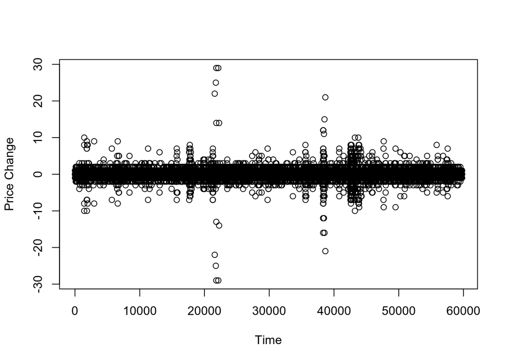

```r
ibm91_ads <- read.table("data/ibm91-ads.dat", header=F )
colnames(ibm91_ads) <- c("A", "D", "S")
plot(ibm91_ads$S*ibm91_ads$D, xlab="Time", ylab="Price Change")
```

Let’s fit the ADS model to the data:

```r
ADS <- stan_model("models/Chapter_5/ADS.stan")
fit_ADS <- sampling(ADS, data = list(N = length(ibm91_ads$A), A=ibm91_ads$A, D=ibm91_ads$D, S=ibm91_ads$S), chains = 4, cores = 4, iter=2000)
```

As you can see, the parameters recovered by Stan as almost the same as the ones showed in the book (it’s no surprise, we used the exact same analytic likelihood):

```r
print(fit_ADS)
```

[output not shown]

The model estimation allows us to determine many interesting features. For example, we can calculate the probability of a price change depends on whether there was a previous price change:

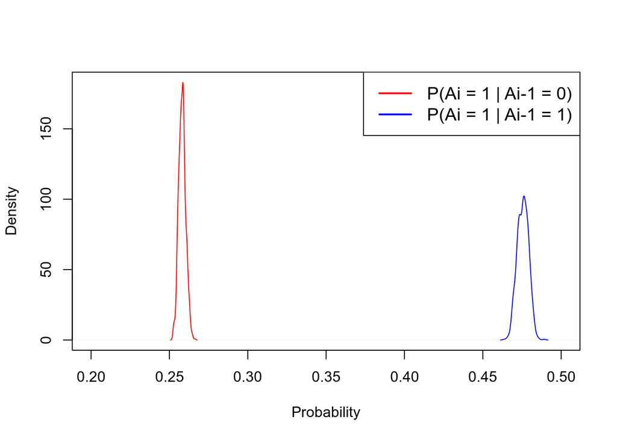

```r
pars <- rstan::extract(fit_ADS)
pA1_0 <- invlogit(pars$beta0 + 0*pars$beta1)
pA1_1 <- invlogit(pars$beta0 + 1*pars$beta1)
plot(density(pA1_0), xlim=c(0.2,0.5), col="red", xlab="Probability", main="")
lines(density(pA1_1), xlim=c(0.2,0.5), col="blue")
legend("topright", legend=c("P(Ai = 1 | Ai-1 = 0)", "P(Ai = 1 | Ai-1 = 1)"), col=c("red", "blue"), lty=1:1, lwd=2, cex=1.2)
```

This plot shows that price change may occur in clusters and, as expected, most transactions are without price change.

Moreover, we can see that

- there is no preference for price increase or decrease after no price change (red line). So little margin for price change prediction.
- Consecutive price increases or decreases are very low (blue line).
- There is evidence of bid-ask spread bounce, as there is high chance of price increase after a price decrease (green line).

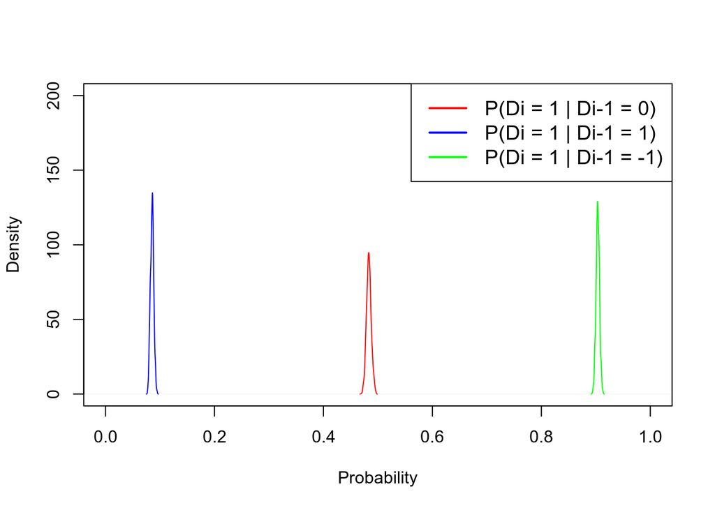

```r
pD1_D0_A0 <- invlogit(pars$gamma0 + 0*pars$gamma1)
pD1_D1_A1 <- invlogit(pars$gamma0 + 1*pars$gamma1)
pD1_D_1_A1 <- invlogit(pars$gamma0 + -1*pars$gamma1)
plot(density(pD1_D0_A0), xlim=c(0,1), ylim=c(0, 200), col="red", xlab="Probability", main="")
lines(density(pD1_D1_A1), xlim=c(0,1), col="blue")
lines(density(pD1_D_1_A1), xlim=c(0,1), col="green")
legend("topright", legend=c("P(Di = 1 | Di-1 = 0)", "P(Di = 1 | Di-1 = 1)", "P(Di = 1 | Di-1 = -1)"), col=c("red", "blue", "green"), lty=1:1, lwd=2, cex=1.2)
```

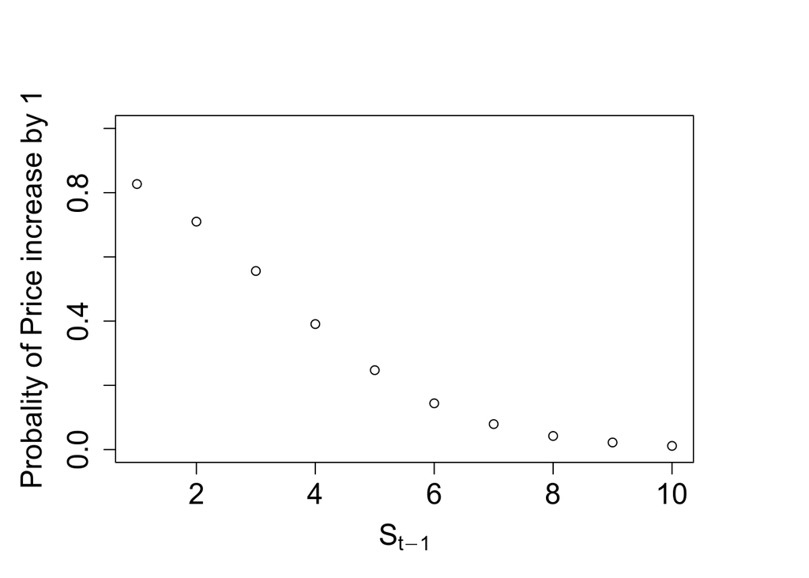

```r
pS <- pgeom(0, prob=invlogit(mean(pars$phi0_u) + (1:10)*mean(pars$phi1_u)))
par(mar=c(5,5,5,5))
plot(pS, ylab = "Probality of Price increase by 1", xlab=expression(S[t-1]), ylim=c(0,1),cex.lab=1.5, cex.axis=1.5)
```

## 5.5 DURATION MODELS

Duration models address the problem of time intervals between trades. Longer time periods between transactions indicate lack of trading activities, meaning that no information can be retrieved during these periods.

### ACD Model

The ACD model can be viewed as an adaptation of GARCH to time durations:

$$x_i = \psi_i \epsilon_i \\
\psi_i = \omega + \sum_{j=1}^{r} \gamma_i x_{i-j} + \sum_{j=1}^{s} \omega_i \psi_{i-j}$$
where *x<sub>i</sub>* is the time elapsed between to consecutive transactions. The error term *<sub>i</sub>* can be modelled with an exponential distribution (EACD), Weibull (WACD) or gamma (GACD).
The ACD model can be coded in Stan as follows:

```stan
data {
  int<lower=0> N;
  vector[N] y;
  int family;
  real psi1;
}
parameters {
  real<lower=0> omega0;
  real<upper=1> omega1;
  real<upper=(1-omega1)> epsilon1;
  real<lower=0> alpha;
  vector<lower=0>[family==1] ka;
}
transformed parameters {
  vector[N] psi;
  psi[1] = psi1;
  for(t in 2:N)
    psi[t] = omega0 + epsilon1 * y[t-1] + omega1 * psi[t-1];
}

model {
  omega0 ~ normal(0.5,0.5);
  omega1 ~ normal(0.5,0.5);
  epsilon1 ~ normal(0.5,0.5);
  alpha ~ normal(1,1);
  ka ~ normal(1,1);
  if(family==0)
    y ~ weibull(alpha, psi);
  else
    y ~ gamma(alpha, 1. ./ (ka[1]*psi));
}
generated quantities {
   vector[N] log_lik;
   {
    if(family==0)
      log_lik[1] = weibull_lpdf(y[1] | alpha, psi[1]);
    else
      log_lik[1] = gamma_lpdf(y[1] | alpha, 1. ./ (ka[1]*psi[1]));

     for (t in 2:(N)) {
       if(psi[t] < 0) {
        log_lik[t] = 0;
        continue;
       }
       if(family==0)
        log_lik[t] = weibull_lpdf(y[t] | alpha, psi[t]);
       else
        log_lik[t] = gamma_lpdf(y[t] | alpha, 1. ./ (ka[1]*psi[t]));
     }
   }
}
```

Let’s apply the WACD to the IBM stock transaction durations on five consecutive trading days from November 1 to November 7, 1990:

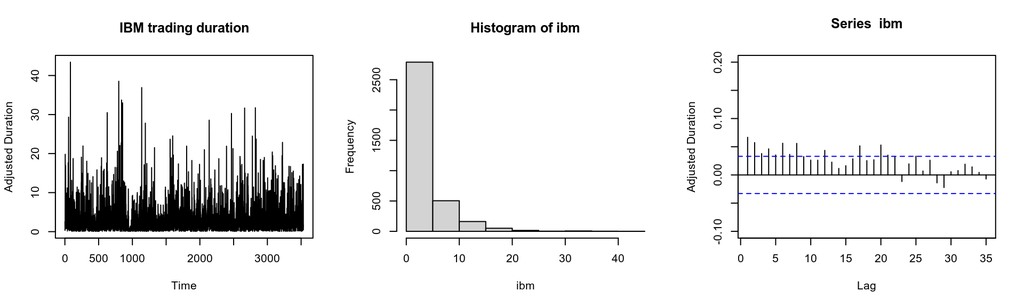

```r
ibm <- scan("data/ibm1to5-dur.txt")
par(mfrow=c(1,3))
plot.ts(ibm, ylab="Adjusted Duration", main="IBM trading duration")
hist(ibm)
Acf(ibm, ylab="Adjusted Duration", ylim=c(-0.1,0.2))
```

```r
ACD <- stan_model("models/Chapter_5/ACD.stan")
fit_ACD_ibm <- sampling(ACD, data = list(N = length(ibm), y=ibm, family=0, psi1=1, M=0, m=vector()), chains = 4, cores = 4, iter=1000, control=list(adapt_delta=0.9))
```

```r
print(fit_ACD_ibm, pars=names(fit_ACD_ibm)[1:4])
```

```
## Inference for Stan model: ACD.
## 4 chains, each with iter=1000; warmup=500; thin=1;
## post-warmup draws per chain=500, total post-warmup draws=2000.
##
##          mean se_mean   sd 2.5%  25%  50%  75% 97.5% n_eff Rhat
## omega0   0.20       0 0.06 0.10 0.15 0.19 0.23  0.34   542 1.01
## omega1   0.87       0 0.03 0.81 0.85 0.87 0.89  0.91   579 1.00
## epsilon1 0.07       0 0.01 0.05 0.06 0.06 0.07  0.09  1182 1.00
## alpha    0.88       0 0.01 0.86 0.87 0.88 0.89  0.90   751 1.00
##
## Samples were drawn using NUTS(diag_e) at Sun Jun  6 09:32:32 2021.
## For each parameter, n_eff is a crude measure of effective sample size,
## and Rhat is the potential scale reduction factor on split chains (at
## convergence, Rhat=1).
```

The parameters recovered are very similar to Tsay’s.  
We can also see that the standardized innovations do not show any sign of serial dependence, confirming the adequacy of the model:

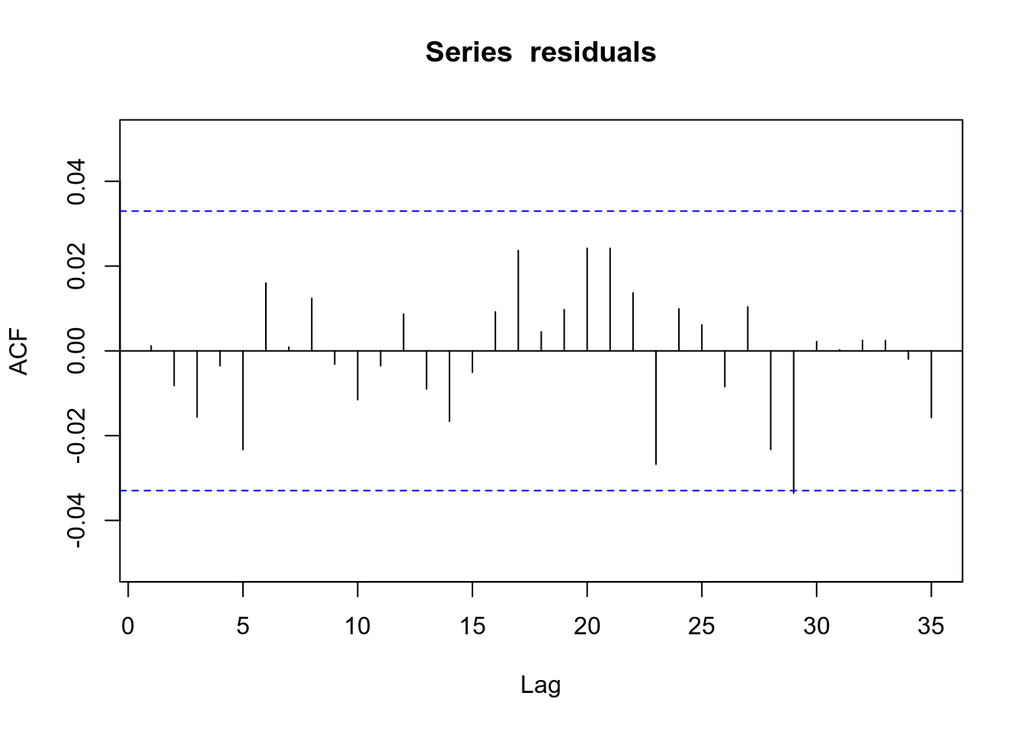

```r
pars <- rstan::extract(fit_ACD_ibm)
residuals <- ibm / colMeans(pars$psi)
Acf(residuals)
```

## 5.6 NONLINEAR DURATION MODELS

We apply Tsay’s test for nonlinearity on the residuals from the WACD model discussed before. This test against the null hypothesis that the time series follows some AR process, we see that the test suggests the presence of non-linearity:

```r
Tsay(residuals, p = 4)
```

```
## Non-linearity test & its p-value:  1.89638 0.04110427
## Degrees of freedom of the test:  10 3519
```

We therefore fit a threshold WACD model to the data (see the file TAR-ACD.stan to see the implementation in Stan), assuming two regimes with a threshold of 3.79:

```r
TARACD <- stan_model("models/Chapter_5/TAR-ACD.stan")
fit_TARACD_ibm <- readRDS("models/Chapter_5/saved_RDS/fit_TARACD_ibm.rds")
```

```r
TARACD <- stan_model("models/Chapter_5/TAR-ACD.stan")
fit_TARACD_ibm <- sampling(TARACD, data = list(N = length(ibm), y=ibm, threshold=3.79, psi1=1, M=0, m=vector()), chains = 4, cores = 4, iter=1000, control=list(adapt_delta=0.90))
```

We can see that parameters estimation is similar to Tsay, and that the non-linearity in the residuals is removed. Moreover, loo comparison seems to strongly prefer the non-linear model:

```r
print(fit_TARACD_ibm, pars=names(fit_TARACD_ibm)[1:8])
```

```
## Inference for Stan model: TAR-ACD.
## 4 chains, each with iter=1000; warmup=500; thin=1;
## post-warmup draws per chain=500, total post-warmup draws=2000.
##
##            mean se_mean   sd 2.5%  25%  50%  75% 97.5% n_eff Rhat
## omega0_l   0.15    0.00 0.06 0.06 0.11 0.14 0.18  0.28   849 1.00
## omega0_g   0.89    0.01 0.25 0.45 0.71 0.88 1.05  1.40   609 1.01
## omega1_l   0.84    0.00 0.03 0.77 0.82 0.85 0.87  0.90   892 1.00
## omega1_g   0.74    0.00 0.08 0.58 0.69 0.75 0.80  0.88   627 1.01
## epsilon1_l 0.15    0.00 0.03 0.09 0.12 0.14 0.16  0.21  1060 1.00
## epsilon1_g 0.03    0.00 0.02 0.00 0.02 0.03 0.04  0.07  2356 1.00
## alpha_l    0.90    0.00 0.01 0.87 0.89 0.90 0.91  0.93  1337 1.00
## alpha_g    0.84    0.00 0.02 0.80 0.83 0.84 0.85  0.88  1619 1.00
##
## Samples were drawn using NUTS(diag_e) at Sun Jun  6 10:25:01 2021.
## For each parameter, n_eff is a crude measure of effective sample size,
## and Rhat is the potential scale reduction factor on split chains (at
## convergence, Rhat=1).
```

```r
pars <- rstan::extract(fit_TARACD_ibm)
residuals_nl <- ibm / colMeans(pars$psi)
Tsay(residuals, p = 4)
```

```
## Non-linearity test & its p-value:  1.89638 0.04110427
## Degrees of freedom of the test:  10 3519
```

```r
Tsay(residuals_nl, p = 4)
```

```
## Non-linearity test & its p-value:  1.384131 0.1808949
## Degrees of freedom of the test:  10 3519
```

```r
loo_compare(loo(fit_ACD_ibm), loo(fit_TARACD_ibm))
```

```
##        elpd_diff se_diff
## model2   0.0       0.0
## model1 -14.8       5.2
```

## 5.7 BIVARIATE MODELS FOR PRICE CHANGE AND DURATION

We now introduce a combined model for both price change and transaction duration. The PCD model focus on transactions that result in price change. According to this model and the notation described before, stock prices evolve over time as:

$$P_{t_i} = P_{t_i-1} + D_iS_i$$
The PCD model can be coded in Stan as follows:

```stan
functions {
  real geometric(real y, real phi){
    return(log(phi * (1 - phi)^y));
  }

}

data {
  int<lower=0> T; // length of data
  vector[T] log_dt; // log of time durations
  vector[T] D; // direction of movement
  int S[T]; // size of price change
  vector[T] N; // number of transactions
}

parameters {
  real  beta0 ;
  real  beta1 ;
  real  beta2 ;
  real<lower=0>  sigma ;
  real  alpha0 ;
  real  alpha1 ;
  real  gamma0 ;
  real  gamma1 ;
  real  omega0 ;
  real  omega1 ;
  real  omega2 ;
  real  Dbeta ;
  real  eta0_d ;
  real  eta1_d ;
  real  eta2_d ;
  real  eta3_d ;
  real  eta0_u ;
  real  eta1_u ;
  real  eta2_u ;
  real  eta3_u ;
}

model {
  sigma ~ cauchy(0,1);
  beta0 ~ normal(0,5);
  beta1 ~ normal(0,1);
  beta2 ~ normal(0,1);
  gamma0 ~ normal(0,5);
  gamma1 ~ normal(0,5);
  alpha0 ~ normal(0,5);
  alpha1 ~ normal(0,5);
  omega0 ~ normal(0,5);
  omega1 ~ normal(0,5);
  omega2 ~ normal(0,5);
  Dbeta ~ normal(0,1);
  eta0_d ~ normal(0,5);
  eta1_d ~ normal(0,5);
  eta2_d ~ normal(0,5);
  eta3_d ~ normal(0,5);
  eta0_u ~ normal(0,5);
  eta1_u ~ normal(0,5);
  eta2_u ~ normal(0,5);
  eta3_u ~ normal(0,5);

  for(t in 5:T) {
    // formula (5.48)
    log_dt[t] ~ normal(beta0 + beta1*log_dt[t-1] + beta2*S[t-1], sigma);
    // formula (5.49) and (5.50)
    if (N[t] == 0)
      target += bernoulli_logit_lpmf(0 | alpha0 + alpha1*log_dt[t]);
    else
      target += bernoulli_logit_lpmf(1 | alpha0 + alpha1*log_dt[t])
                              + geometric(N[t]-1, inv_logit(gamma0 + gamma1*log_dt[t]));
    // we use the comulative normal to represent formula (5.51), nice trick!
    (D[t]==1) ~ bernoulli(normal_cdf(0, omega0 + omega1*D[t-1] + omega2*log_dt[t], exp(Dbeta * fabs(sum(D[(t-4):(t-1)])))));
    // formulas (5.52) and (5.53)
    if(D[t] == -1)
      (S[t]-1) ~ poisson(exp( eta0_d + eta1_d*log(N[t]+1) + eta2_d*log_dt[t] + eta3_d*S[t-1]));
    else
      (S[t]-1) ~ poisson(exp( eta0_u + eta1_u*log(N[t]+1) + eta2_u*log_dt[t] + eta3_u*S[t-1]));
  }
}
```

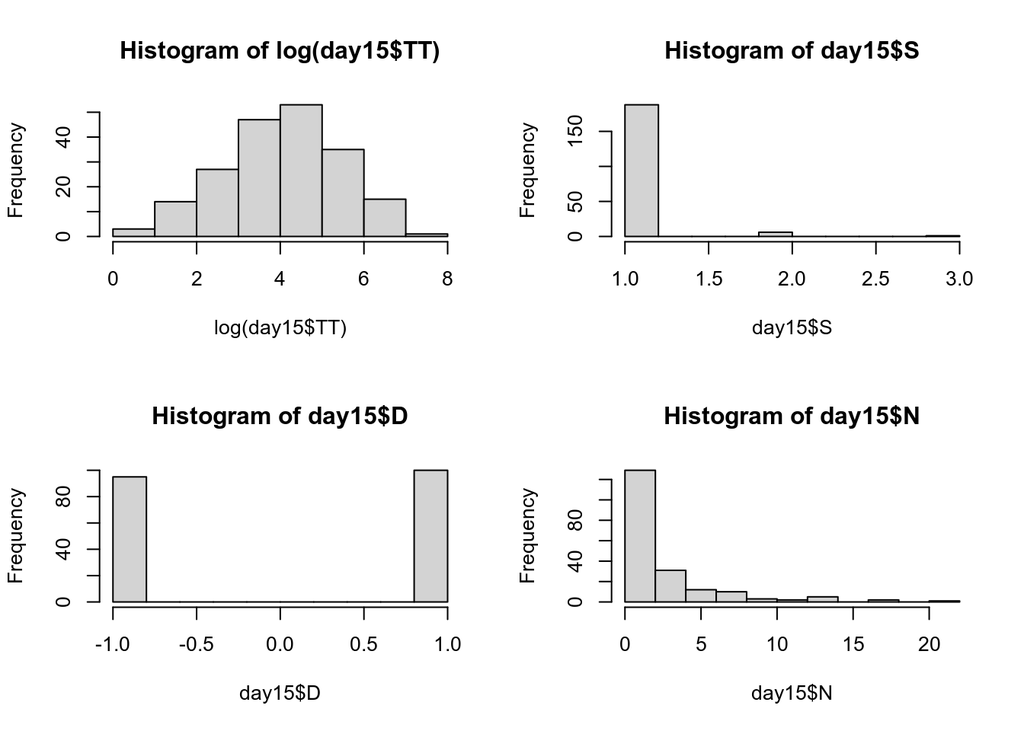

```r
day15 <- read.csv("data/day15v.dat", header = F, sep="\t")
colnames(day15) <- c("Day", "Time", "TT", "D", "S", "N", "I", "C")
par(mfrow=c(2,2))
hist(log(day15$TT)); hist(day15$S); hist(day15$D); hist(day15$N)
```

```r
PCD <- stan_model("models/Chapter_5/PCD.stan")
fit_PCD<- sampling(PCD, data = list(T = nrow(day15), log_dt=log(day15$TT), D=day15$D, S=day15$S, N=day15$N), chains = 4, cores = 4, iter=1000, control=list(adapt_delta=0.90))
```

```r
print(fit_PCD)
```

```
## Inference for Stan model: PCD.
## 4 chains, each with iter=1000; warmup=500; thin=1;
## post-warmup draws per chain=500, total post-warmup draws=2000.
##
##           mean se_mean   sd    2.5%     25%     50%     75%   97.5% n_eff Rhat
## beta0     3.89    0.01 0.52    2.89    3.53    3.88    4.27    4.92  2233    1
## beta1     0.04    0.00 0.07   -0.10   -0.01    0.05    0.10    0.18  2998    1
## beta2    -0.05    0.01 0.41   -0.85   -0.32   -0.05    0.23    0.74  2539    1
## sigma     1.45    0.00 0.08    1.30    1.39    1.44    1.50    1.61  2266    1
## alpha0   -6.86    0.02 0.98   -8.89   -7.49   -6.83   -6.17   -4.98  2198    1
## alpha1    1.74    0.01 0.24    1.29    1.58    1.74    1.89    2.23  2209    1
## gamma0    3.22    0.01 0.69    1.88    2.73    3.23    3.69    4.59  2560    1
## gamma1   -0.85    0.00 0.13   -1.11   -0.94   -0.85   -0.76   -0.59  2518    1
## omega0   -0.12    0.01 0.37   -0.87   -0.36   -0.12    0.12    0.58  1998    1
## omega1    0.79    0.00 0.13    0.54    0.70    0.78    0.87    1.04  2810    1
## omega2    0.01    0.00 0.08   -0.15   -0.05    0.00    0.06    0.17  2035    1
## Dbeta     0.28    0.01 0.24   -0.07    0.13    0.24    0.38    0.82  1016    1
## eta0_d   -1.05    0.09 3.21   -7.08   -3.20   -1.19    0.98    5.51  1250    1
## eta1_d   -0.70    0.03 1.09   -2.83   -1.39   -0.68   -0.02    1.47  1867    1
## eta2_d    0.26    0.02 0.62   -0.89   -0.17    0.24    0.66    1.54  1405    1
## eta3_d   -3.35    0.08 2.87   -9.64   -5.15   -3.06   -1.17    1.16  1259    1
## eta0_u   -4.36    0.04 1.88   -7.97   -5.63   -4.41   -3.11   -0.63  1799    1
## eta1_u   -2.26    0.04 1.49   -5.82   -3.10   -2.01   -1.21    0.02  1354    1
## eta2_u    0.22    0.01 0.40   -0.51   -0.05    0.21    0.48    1.08  2221    1
## eta3_u    0.85    0.04 1.44   -2.37    0.05    1.03    1.86    3.27  1521    1
## lp__   -611.89    0.11 3.22 -619.29 -613.78 -611.63 -609.63 -606.56   829    1
##
## Samples were drawn using NUTS(diag_e) at Sun Jun  6 10:55:09 2021.
## For each parameter, n_eff is a crude measure of effective sample size,
## and Rhat is the potential scale reduction factor on split chains (at
## convergence, Rhat=1).
```

We can see that parameter estimation is pretty close to Tsay.